# Proyecto N° 1

Mateo Cornejo De la Rosa

20/2/2022

# **Caso N° 1: Siniestros en Seguros**

Se tiene un conjunto de datos simulado basado en seis meses de la información recogida por una aseguradora mundial llamada **“VIDA SEGUROS”**, cuyo objetivo fue desarrollar un modelo para determinar la probabilidad de siniestro en los próximos 12 meses. La variable de destino es la siniestralidad, que representa el estado binario de No Siniestro 0 y Siniestro 1.

## **Descripción de las Variables:**

###### **Cliente_ID:** Identificador de cliente.

###### **Antigüedad_Maxima:** Antigüedad del cliente en meses.

###### **Nivel_Ingresos:** Nivel de ingresos de 0 (bajo) a 5 (alto).

###### **Saldo_Pendiente:** Saldo pendiente del cliente.

###### **Puntaje_Morosidad:** Tasa de morosidad en el seguro. O: No Dq., 1: 1-29, …, 6: 150-179.

###### **Saldo_Pendiente_Seg:** Saldo pendiente de la póliza del seguro.

###### **Siniestros:** Número de siniestros en la historia del cliente.

###### **Estado_Siniestro:** 0: No Siniestro, 1: Siniestro.

## **Establecemos nuestra ruta de trabajo:**

```r
setwd('C:/Estadistica.Data.Science.R/Proyecto.20pct')
getwd()
```

```
## [1] "C:/Estadistica.Data.Science.R/Proyecto.20pct"
```

## **Importar la base de datos de nuestro proyecto:**

```r
DatosSeguros <- read.csv("Datos/Data_Siniestros en Seguros .csv", sep=",")
```

## **Vizualizamos los 6 primeros registros:**

```r
head(DatosSeguros)
```

```
##   Cliente_ID Antigüedad_Maxima Nivel_Ingresos Saldo_Pendiente
## 1        185                44              1          604.86
## 2        238                79              1         1006.21
## 3        346               102              1          299.23
## 4        460                NA              1          645.19
## 5        549               109             NA          218.00
## 6        559               183             NA           10.32
##   Puntaje_Morosidad1 Puntaje_Morosidad2 Puntaje_Morosidad3 Puntaje_Morosidad4
## 1                  0                  0                  0                  0
## 2                  0                  0                  0                  0
## 3                  0                  0                  0                  0
## 4                  0                  0                  0                  0
## 5                  0                  0                  0                  0
## 6                  0                  0                  0                  0
##   Puntaje_Morosidad5 Puntaje_Morosidad6 Saldo_Pendiente_Seg Siniestros1
## 1                  0                  0                   0           0
## 2                  0                  0                   0           0
## 3                  0                  0                   0           0
## 4                  0                  0                   0           0
## 5                  0                  0                   0           0
## 6                  0                  0                   0           0
##   Siniestros2 Siniestros3 Siniestros4 Siniestros5 Siniestros6 Estado_Siniestro
## 1           0           0           0           0           0               no
## 2           0           0           0           0           0               no
## 3           0           0           0           0           0               no
## 4           0           0           0           0           0               no
## 5           0           0           0           0           0               no
## 6           0           0           0           0           0               no
```

Con esta primera vista de los datos, podemos darnos una idea de la forma que debería tener la tabla. En la siguiente salida revisaremos esta estructura.

## **Estructura de la base de datos:**

```r
str(DatosSeguros)
```

```
## 'data.frame':    5800 obs. of  18 variables:
##  $ Cliente_ID         : int  185 238 346 460 549 559 666 676 696 907 ...
##  $ Antigüedad_Maxima  : int  44 79 102 NA 109 183 172 76 136 171 ...
##  $ Nivel_Ingresos     : int  1 1 1 1 NA NA 0 1 0 0 ...
##  $ Saldo_Pendiente    : num  605 1006 299 645 218 ...
##  $ Puntaje_Morosidad1 : int  0 0 0 0 0 0 0 0 0 0 ...
##  $ Puntaje_Morosidad2 : int  0 0 0 0 0 0 0 0 0 0 ...
##  $ Puntaje_Morosidad3 : int  0 0 0 0 0 0 0 1 0 0 ...
##  $ Puntaje_Morosidad4 : int  0 0 0 0 0 0 0 0 0 0 ...
##  $ Puntaje_Morosidad5 : int  0 0 0 0 0 0 0 0 0 0 ...
##  $ Puntaje_Morosidad6 : int  0 0 0 0 0 0 0 0 0 0 ...
##  $ Saldo_Pendiente_Seg: num  0 0 0 0 0 0 0 0 0 0 ...
##  $ Siniestros1        : int  0 0 0 0 0 0 0 0 0 0 ...
##  $ Siniestros2        : int  0 0 0 0 0 0 0 0 0 0 ...
##  $ Siniestros3        : int  0 0 0 0 0 0 0 0 0 0 ...
##  $ Siniestros4        : int  0 0 0 0 0 0 0 1 0 0 ...
##  $ Siniestros5        : int  0 0 0 0 0 0 0 1 0 0 ...
##  $ Siniestros6        : int  0 0 0 0 0 0 0 1 0 0 ...
##  $ Estado_Siniestro   : chr  "no" "no" "no" "no" ...
```

Revisando la estructura de la tabla encontramos lo siguiente:

#### **Dimensiones:**

- Nuestra base de datos tiene 5800 registros y 18 variables. También se podría obtener con dim(DatosSeguros).

#### **Variables:**

###### - **Cliente_ID**: Como es la llave de la tabla, no debería ser entero, porque no vamos a sacar ningún estadístico de resumen. Lo cambiaremos a CARACTER.

###### - **Antigüedad_Maxima**: El tipo de datos es correcto. Queda como ENTERO.

###### - **Nivel_Ingresos**: De acuerdo a la formulación del caso, es una variable categórica ordinal (de bajo a alto). Lo cambiaremos a FACTOR.

###### - **Saldo_Pendiente**: El tipo de datos es correcto. Queda como NUMÉRICO.

###### - **Puntaje_MorosidadX**: De acuerdo a la formulación del caso, es una variable categórica ordinal (Rangos de score). Lo cambiaremos a FACTOR.

###### - **Saldo_Pendiente_Seg**: El tipo de datos es correcto. Queda como NUMÉRICO.

###### - **SiniestrosX**: El tipo de datos es correcto. Queda como ENTERO.

###### - **Estado_Siniestro**: De acuerdo a la formulación del caso, es nuestra variable objetivo, de momento lo dejaremos en caracter porque debemos hacer una limpieza de la base de datos. Luego lo cambiaremos a FACTOR.

## **Conversión del Tipo de variables:**

```r
DatosSeguros$Cliente_ID <- as.character(DatosSeguros$Cliente_ID)
DatosSeguros$Nivel_Ingresos <- as.factor(as.character(DatosSeguros$Nivel_Ingresos))
DatosSeguros$Puntaje_Morosidad1 <- as.factor(as.character(DatosSeguros$Puntaje_Morosidad1))
DatosSeguros$Puntaje_Morosidad2 <- as.factor(as.character(DatosSeguros$Puntaje_Morosidad2))
DatosSeguros$Puntaje_Morosidad3 <- as.factor(as.character(DatosSeguros$Puntaje_Morosidad3))
DatosSeguros$Puntaje_Morosidad4 <- as.factor(as.character(DatosSeguros$Puntaje_Morosidad4))
DatosSeguros$Puntaje_Morosidad5 <- as.factor(as.character(DatosSeguros$Puntaje_Morosidad5))
DatosSeguros$Puntaje_Morosidad6 <- as.factor(as.character(DatosSeguros$Puntaje_Morosidad6))

str(DatosSeguros)
```

```
## 'data.frame':    5800 obs. of  18 variables:
##  $ Cliente_ID         : chr  "185" "238" "346" "460" ...
##  $ Antigüedad_Maxima  : int  44 79 102 NA 109 183 172 76 136 171 ...
##  $ Nivel_Ingresos     : Factor w/ 6 levels "0","1","2","3",..: 2 2 2 2 NA NA 1 2 1 1 ...
##  $ Saldo_Pendiente    : num  605 1006 299 645 218 ...
##  $ Puntaje_Morosidad1 : Factor w/ 7 levels "0","1","2","3",..: 1 1 1 1 1 1 1 1 1 1 ...
##  $ Puntaje_Morosidad2 : Factor w/ 8 levels "0","1","2","3",..: 1 1 1 1 1 1 1 1 1 1 ...
##  $ Puntaje_Morosidad3 : Factor w/ 8 levels "0","1","2","3",..: 1 1 1 1 1 1 1 2 1 1 ...
##  $ Puntaje_Morosidad4 : Factor w/ 8 levels "0","1","2","3",..: 1 1 1 1 1 1 1 1 1 1 ...
##  $ Puntaje_Morosidad5 : Factor w/ 8 levels "0","1","2","3",..: 1 1 1 1 1 1 1 1 1 1 ...
##  $ Puntaje_Morosidad6 : Factor w/ 8 levels "0","1","2","3",..: 1 1 1 1 1 1 1 1 1 1 ...
##  $ Saldo_Pendiente_Seg: num  0 0 0 0 0 0 0 0 0 0 ...
##  $ Siniestros1        : int  0 0 0 0 0 0 0 0 0 0 ...
##  $ Siniestros2        : int  0 0 0 0 0 0 0 0 0 0 ...
##  $ Siniestros3        : int  0 0 0 0 0 0 0 0 0 0 ...
##  $ Siniestros4        : int  0 0 0 0 0 0 0 1 0 0 ...
##  $ Siniestros5        : int  0 0 0 0 0 0 0 1 0 0 ...
##  $ Siniestros6        : int  0 0 0 0 0 0 0 1 0 0 ...
##  $ Estado_Siniestro   : chr  "no" "no" "no" "no" ...
```

Ahora las variables tienen su correcto tipo de datos. Revisemos la variable Estado_Siniestro.

## **Target: Estado_Siniestro:**

```r
table(DatosSeguros$Estado_Siniestro)
```

```
##
##        no   si
## 1068 4236  496
```

```r
round(table(DatosSeguros$Estado_Siniestro) / nrow(DatosSeguros) * 100, 2)
```

```
##
##          no    si
## 18.41 73.03  8.55
```

Podemos obsevar que hay 1,068 casos que no tiene etique (si/no). Al parecer la base de datos contiene una base de 4,732 registros para hacer el modelo y 1,068 para la predicción. Por lo tanto, vamos a separar las bases y nos quedamos con la base con 4,732 registros.

## **Guardar nuestros datasets:**

```r
DatosSegurosModelo <- DatosSeguros[DatosSeguros$Estado_Siniestro != '', ]
DatosSegurosPrediccion <- DatosSeguros[DatosSeguros$Estado_Siniestro == '', ]

save(DatosSegurosModelo, file = 'Datos/DatosSegurosModelo.RData')
save(DatosSegurosPrediccion, file = 'Datos/DatosSegurosPrediccion.RData')
```

Desde ahora trabajaremos con el Dataset **DatosSegurosModelo**. Previamente cambiando el tipo de variable de Estado_Siniestro a Factor

#### **Resumen del dataset:**

```r
DatosSegurosModelo$Estado_Siniestro <- as.factor(DatosSegurosModelo$Estado_Siniestro)
summary(DatosSegurosModelo)
```

```
##   Cliente_ID        Antigüedad_Maxima Nivel_Ingresos Saldo_Pendiente
##  Length:4732        Min.   :  6.00    0   :1415      Min.   :     0.01
##  Class :character   1st Qu.: 16.00    1   :2075      1st Qu.:   465.09
##  Mode  :character   Median : 41.00    2   : 226      Median :  1299.42
##                     Mean   : 54.98    3   : 494      Mean   :  3660.04
##                     3rd Qu.: 82.00    4   : 238      3rd Qu.:  3910.11
##                     Max.   :255.00    5   :  53      Max.   :124102.08
##                     NA's   :482       NA's: 231
##  Puntaje_Morosidad1 Puntaje_Morosidad2 Puntaje_Morosidad3 Puntaje_Morosidad4
##  0:4241             0      :4215       0      :4247       0      :4289
##  1: 295             1      : 326       1      : 338       1      : 322
##  2: 101             2      : 117       2      :  84       2      :  64
##  3:  95             3      :  35       7      :  25       7      :  21
##  4:   0             7      :  32       3      :  21       3      :  14
##  5:   0             4      :   5       (Other):  16       (Other):  19
##  6:   0             (Other):   2       NA's   :   1       NA's   :   3
##  Puntaje_Morosidad5 Puntaje_Morosidad6 Saldo_Pendiente_Seg  Siniestros1
##  0      :4278       0      :4294       Min.   :     0      Min.   : 0.0000
##  1      : 331       1      : 338       1st Qu.:     0      1st Qu.: 0.0000
##  2      :  68       2      :  46       Median :     0      Median : 0.0000
##  7      :  19       7      :  20       Mean   :  5549      Mean   : 0.6338
##  4      :  13       3      :  18       3rd Qu.:     0      3rd Qu.: 0.0000
##  (Other):  19       (Other):  12       Max.   :442335      Max.   :42.0000
##  NA's   :   4       NA's   :   4
##   Siniestros2       Siniestros3      Siniestros4       Siniestros5
##  Min.   : 0.0000   Min.   : 0.000   Min.   : 0.0000   Min.   : 0.000
##  1st Qu.: 0.0000   1st Qu.: 0.000   1st Qu.: 0.0000   1st Qu.: 0.000
##  Median : 0.0000   Median : 0.000   Median : 0.0000   Median : 0.000
##  Mean   : 0.5507   Mean   : 0.493   Mean   : 0.4607   Mean   : 0.418
##  3rd Qu.: 0.0000   3rd Qu.: 0.000   3rd Qu.: 0.0000   3rd Qu.: 0.000
##  Max.   :40.0000   Max.   :40.000   Max.   :40.0000   Max.   :40.000
##
##   Siniestros6      Estado_Siniestro
##  Min.   : 0.0000   no:4236
##  1st Qu.: 0.0000   si: 496
##  Median : 0.0000
##  Mean   : 0.3848
##  3rd Qu.: 0.0000
##  Max.   :40.0000
##
```

```r
round(table(DatosSegurosModelo$Estado_Siniestro)/nrow(DatosSegurosModelo) * 100,2)
```

```
##
##    no    si
## 89.52 10.48
```

Con este vistazo inicial de los datos, podemos ir analizando la información:

## **APLICANDO ESTADÍSTICA DESCRIPTIVA**

### **1. Antigüedad_Maxima:**

#### **Medidas de Tendencia Central y Medidas de Posición:**

```r
# if (require("modeest")) install.packages("modeest")
library('modeest')
paste('Media = ', mean(DatosSegurosModelo$Antigüedad_Maxima, na.rm = T))
```

```
## [1] "Media =  54.9842352941176"
```

```r
paste('Mediana = ', median(DatosSegurosModelo$Antigüedad_Maxima, na.rm = T))
```

```
## [1] "Mediana =  41"
```

```r
paste('Moda = ', mlv(DatosSegurosModelo$Antigüedad_Maxima, method = "mfv", na.rm = T))
```

```
## [1] "Moda =  7"
```

```r
paste('Percentiles:')
```

```
## [1] "Percentiles:"
```

```r
quantile(DatosSegurosModelo$Antigüedad_Maxima, c(0.01, 0.05, 0.10, 0.20, 0.25, 0.30, 0.40, 0.50, 0.60, 0.70, 0.75, 0.80, 0.90, 0.95, 0.99), na.rm = T)
```

```
##  1%  5% 10% 20% 25% 30% 40% 50% 60% 70% 75% 80% 90% 95% 99%
##   6   7   9  13  16  20  29  41  55  71  82  93 123 155 199
```

```r
paste('Histograma:')
```

```
## [1] "Histograma:"
```

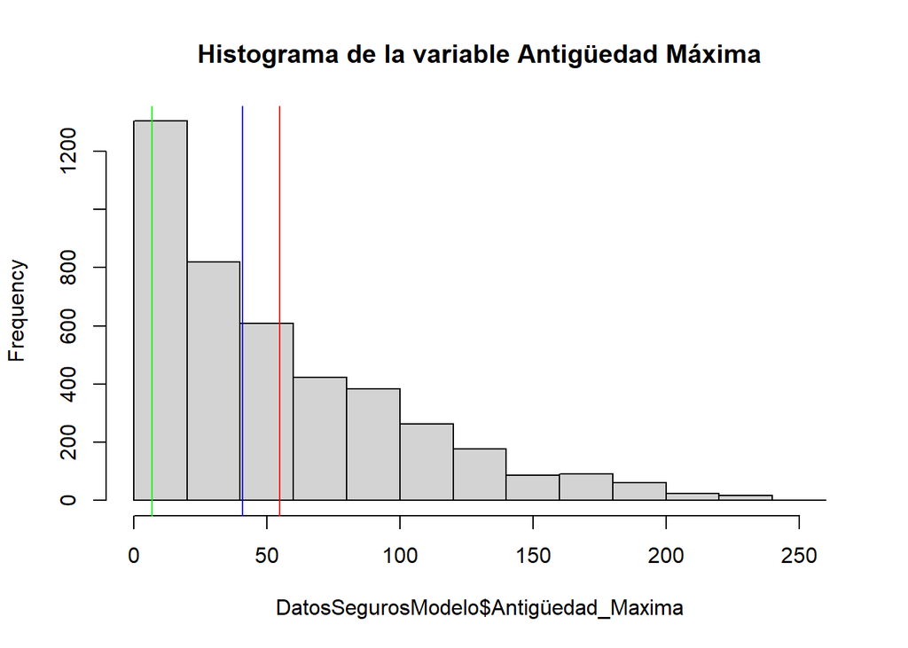

```r
hist(DatosSegurosModelo$Antigüedad_Maxima, main= "Histograma de la variable Antigüedad Máxima")
abline(v=mean(DatosSegurosModelo$Antigüedad_Maxima, na.rm = T), col="red")
abline(v=median(DatosSegurosModelo$Antigüedad_Maxima, na.rm = T), col="blue")
abline(v=mlv(DatosSegurosModelo$Antigüedad_Maxima, method = "mfv", na.rm = T), col="green")
```

```r
paste('Boxplot:')
```

```
## [1] "Boxplot:"
```

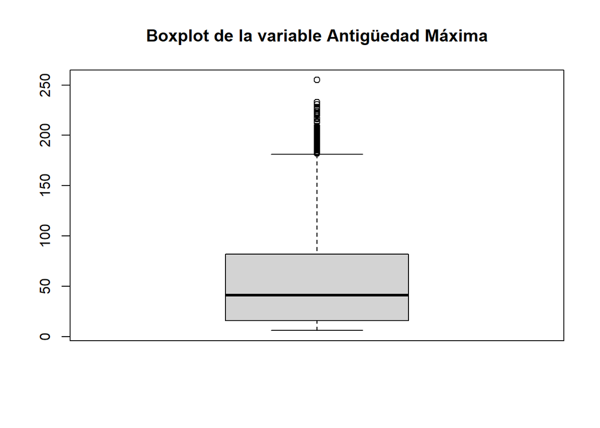

```r
boxplot(DatosSegurosModelo$Antigüedad_Maxima, main= "Boxplot de la variable Antigüedad Máxima")
```

#### **Medidas de Dispersión:**

```r
paste('Desviación Estándar: ', sd(DatosSegurosModelo$Antigüedad_Maxima, na.rm = TRUE))
```

```
## [1] "Desviación Estándar:  47.4384910835345"
```

```r
paste('Varianza: ', sd(DatosSegurosModelo$Antigüedad_Maxima, na.rm = TRUE)^2)
```

```
## [1] "Varianza:  2250.41043628259"
```

```r
paste('Coeficiente de Variación: ', sd(DatosSegurosModelo$Antigüedad_Maxima, na.rm = TRUE) / mean(DatosSegurosModelo$Antigüedad_Maxima, na.rm = T) * 100)
```

```
## [1] "Coeficiente de Variación:  86.2765314999473"
```

#### **Asimetría y Curtosis:**

```r
library(e1071)
skewness(DatosSegurosModelo$Antigüedad_Maxima, na.rm = TRUE)
```

```
## [1] 1.198396
```

```r
kurtosis(DatosSegurosModelo$Antigüedad_Maxima, na.rm = TRUE)
```

```
## [1] 0.9634417
```

### **2. Nivel de Ingresos:**

#### **Frecuencia Absoluta y Frecuencia Relativa**

```r
# if (require("modeest")) install.packages("modeest")
library('modeest')
paste('Moda = ', mlv(DatosSegurosModelo$Nivel_Ingresos, method = "mfv", na.rm = T))
```

```
## [1] "Moda =  1"
```

```r
table(DatosSegurosModelo$Nivel_Ingresos)
```

```
##
##    0    1    2    3    4    5
## 1415 2075  226  494  238   53
```

```r
round(table(DatosSegurosModelo$Nivel_Ingresos) / nrow(DatosSegurosModelo) * 100, 2)
```

```
##
##     0     1     2     3     4     5
## 29.90 43.85  4.78 10.44  5.03  1.12
```

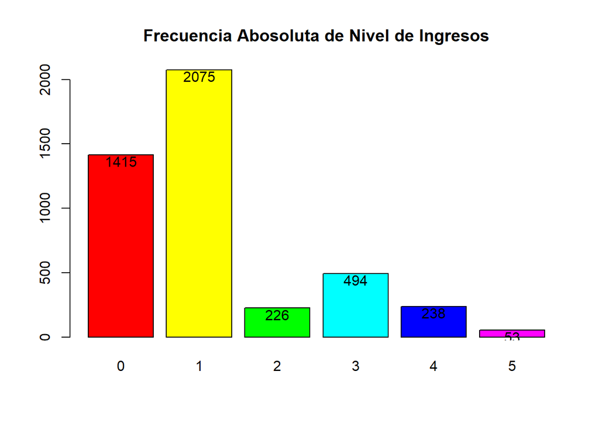

```r
a <- barplot(table(DatosSegurosModelo$Nivel_Ingresos), main = 'Frecuencia Abosoluta de Nivel de Ingresos', col = rainbow(6))
text(a, table(DatosSegurosModelo$Nivel_Ingresos) - 50, labels = table(DatosSegurosModelo$Nivel_Ingresos))
```

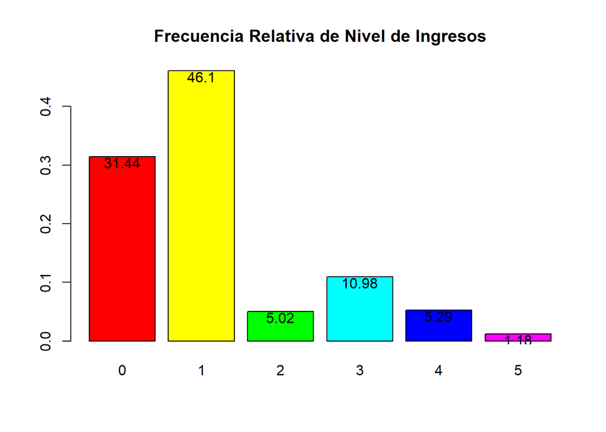

```r
b <- barplot(prop.table(table(DatosSegurosModelo$Nivel_Ingresos)), main = 'Frecuencia Relativa de Nivel de Ingresos', col = rainbow(6))
text(b, prop.table(table(DatosSegurosModelo$Nivel_Ingresos)) - 0.01, labels = round(prop.table(table(DatosSegurosModelo$Nivel_Ingresos)), 4)*100)
```

### **3. Saldo Pendiente:**

#### **Medidas de Tendencia Central y Medidas de Posición:**

```r
# if (require("modeest")) install.packages("modeest")
library('modeest')
paste('Media = ', mean(DatosSegurosModelo$Saldo_Pendiente, na.rm = T))
```

```
## [1] "Media =  3660.03516694844"
```

```r
paste('Mediana = ', median(DatosSegurosModelo$Saldo_Pendiente, na.rm = T))
```

```
## [1] "Mediana =  1299.42"
```

```r
paste('Moda = ', mlv(DatosSegurosModelo$Saldo_Pendiente, method = "mfv", na.rm = T))
```

```
## [1] "Moda =  0.01"
```

```r
paste('Percentiles:')
```

```
## [1] "Percentiles:"
```

```r
quantile(DatosSegurosModelo$Saldo_Pendiente, c(0.01, 0.05, 0.10, 0.20, 0.25, 0.30, 0.40, 0.50, 0.60, 0.70, 0.75, 0.80, 0.90, 0.95, 0.99), na.rm = T)
```

```
##         1%         5%        10%        20%        25%        30%        40%
##     0.1100    31.3570   115.1460   333.7540   465.0925   607.0410   895.0420
##        50%        60%        70%        75%        80%        90%        95%
##  1299.4200  1928.7960  3025.1110  3910.1075  5345.3860  9948.1390 15197.2750
##        99%
## 30704.2193
```

```r
paste('Histograma:')
```

```
## [1] "Histograma:"
```

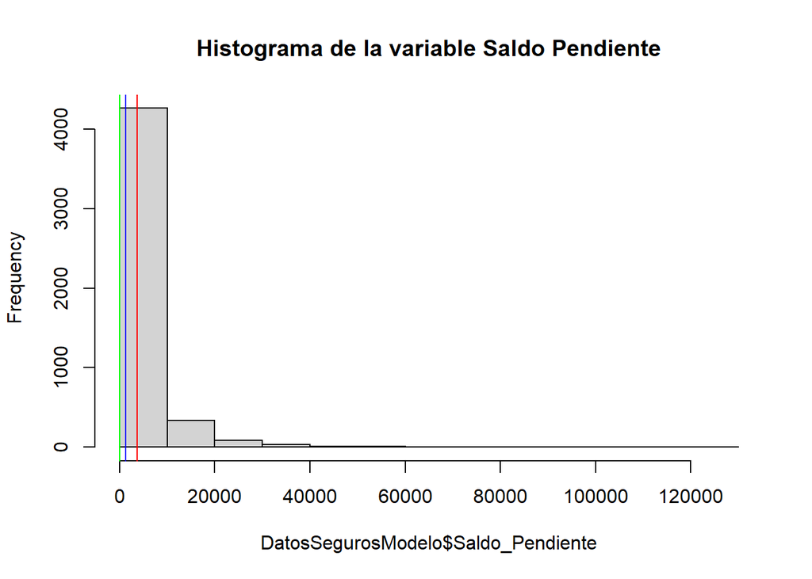

```r
hist(DatosSegurosModelo$Saldo_Pendiente, main= "Histograma de la variable Saldo Pendiente")
abline(v=mean(DatosSegurosModelo$Saldo_Pendiente, na.rm = T), col="red")
abline(v=median(DatosSegurosModelo$Saldo_Pendiente, na.rm = T), col="blue")
abline(v=mlv(DatosSegurosModelo$Saldo_Pendiente, method = "mfv", na.rm = T), col="green")
```

```r
paste('Boxplot:')
```

```
## [1] "Boxplot:"
```

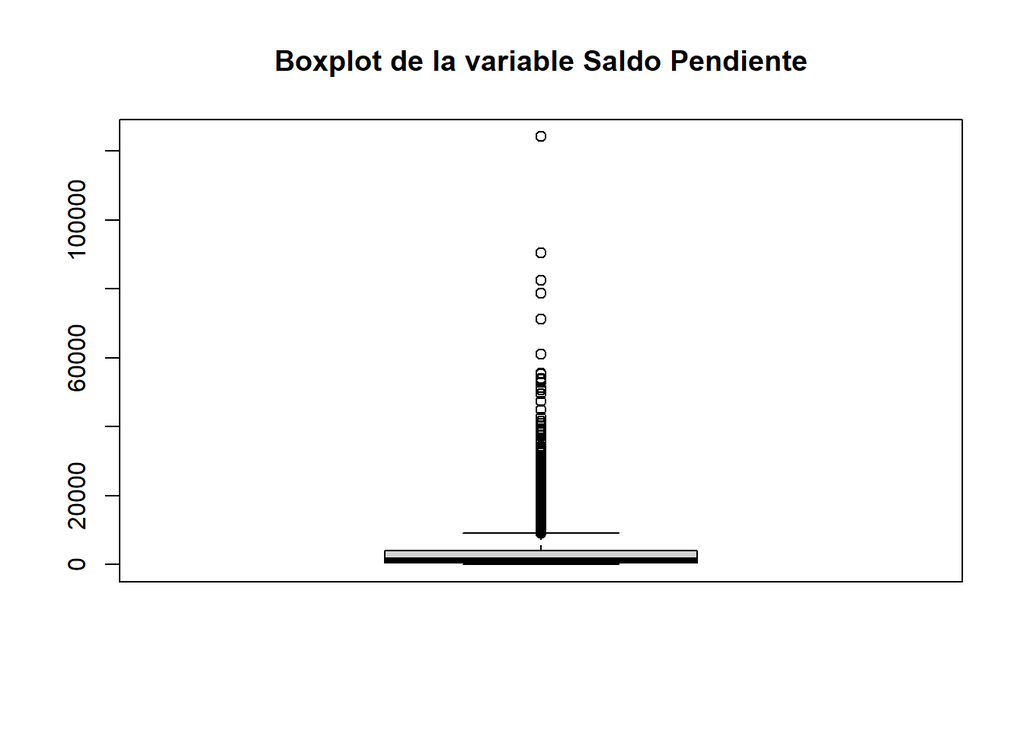

```r
boxplot(DatosSegurosModelo$Saldo_Pendiente, main= "Boxplot de la variable Saldo Pendiente")
```

#### **Medidas de Dispersión:**

```r
paste('Desviación Estándar: ', sd(DatosSegurosModelo$Saldo_Pendiente, na.rm = TRUE))
```

```
## [1] "Desviación Estándar:  6559.25515543992"
```

```r
paste('Varianza: ', sd(DatosSegurosModelo$Saldo_Pendiente, na.rm = TRUE)^2)
```

```
## [1] "Varianza:  43023828.1941652"
```

```r
paste('Coeficiente de Variación: ', sd(DatosSegurosModelo$Saldo_Pendiente, na.rm = TRUE) / mean(DatosSegurosModelo$Saldo_Pendiente, na.rm = T) * 100)
```

```
## [1] "Coeficiente de Variación:  179.212899774095"
```

#### **Asimetría y Curtosis:**

```r
library(e1071)
skewness(DatosSegurosModelo$Saldo_Pendiente, na.rm = TRUE)
```

```
## [1] 5.322782
```

```r
kurtosis(DatosSegurosModelo$Saldo_Pendiente, na.rm = TRUE)
```

```
## [1] 51.81607
```

### **4. Puntaje Morosidad 1:**

#### **Frecuencia Absoluta y Frecuencia Relativa**

```r
# if (require("modeest")) install.packages("modeest")
library('modeest')
paste('Moda = ', mlv(DatosSegurosModelo$Puntaje_Morosidad1, method = "mfv", na.rm = T))
```

```
## [1] "Moda =  0"
```

```r
table(DatosSegurosModelo$Puntaje_Morosidad1)
```

```
##
##    0    1    2    3    4    5    6
## 4241  295  101   95    0    0    0
```

```r
round(table(DatosSegurosModelo$Puntaje_Morosidad1) / nrow(DatosSegurosModelo) * 100, 2)
```

```
##
##     0     1     2     3     4     5     6
## 89.62  6.23  2.13  2.01  0.00  0.00  0.00
```

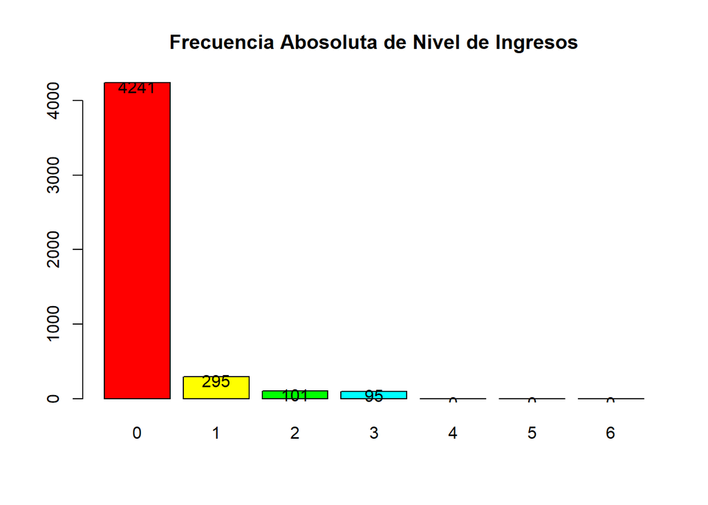

```r
a <- barplot(table(DatosSegurosModelo$Puntaje_Morosidad1), main = 'Frecuencia Abosoluta de Nivel de Ingresos', col = rainbow(6))
text(a, table(DatosSegurosModelo$Puntaje_Morosidad1) - 50, labels = table(DatosSegurosModelo$Puntaje_Morosidad1))
```

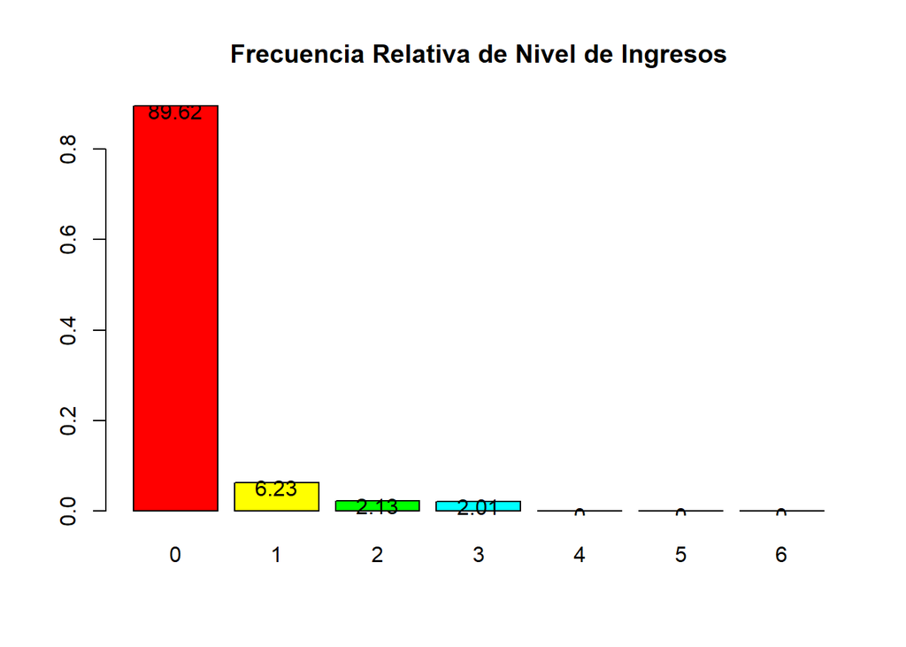

```r
b <- barplot(prop.table(table(DatosSegurosModelo$Puntaje_Morosidad1)), main = 'Frecuencia Relativa de Nivel de Ingresos', col = rainbow(6))
text(b, prop.table(table(DatosSegurosModelo$Puntaje_Morosidad1)) - 0.01, labels = round(prop.table(table(DatosSegurosModelo$Puntaje_Morosidad1)), 4)*100)
```

### **5. Puntaje Morosidad 2:**

#### **Frecuencia Absoluta y Frecuencia Relativa**

```r
# if (require("modeest")) install.packages("modeest")
library('modeest')
paste('Moda = ', mlv(DatosSegurosModelo$Puntaje_Morosidad2, method = "mfv", na.rm = T))
```

```
## [1] "Moda =  0"
```

```r
table(DatosSegurosModelo$Puntaje_Morosidad2)
```

```
##
##    0    1    2    3    4    5    6    7
## 4215  326  117   35    5    1    1   32
```

```r
round(table(DatosSegurosModelo$Puntaje_Morosidad2) / nrow(DatosSegurosModelo) * 100, 2)
```

```
##
##     0     1     2     3     4     5     6     7
## 89.07  6.89  2.47  0.74  0.11  0.02  0.02  0.68
```

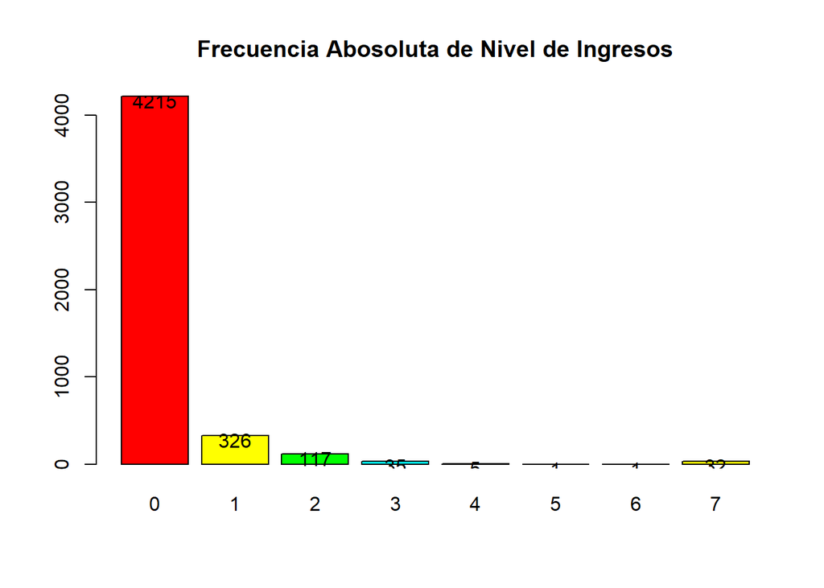

```r
a <- barplot(table(DatosSegurosModelo$Puntaje_Morosidad2), main = 'Frecuencia Abosoluta de Nivel de Ingresos', col = rainbow(6))
text(a, table(DatosSegurosModelo$Puntaje_Morosidad2) - 50, labels = table(DatosSegurosModelo$Puntaje_Morosidad2))
```

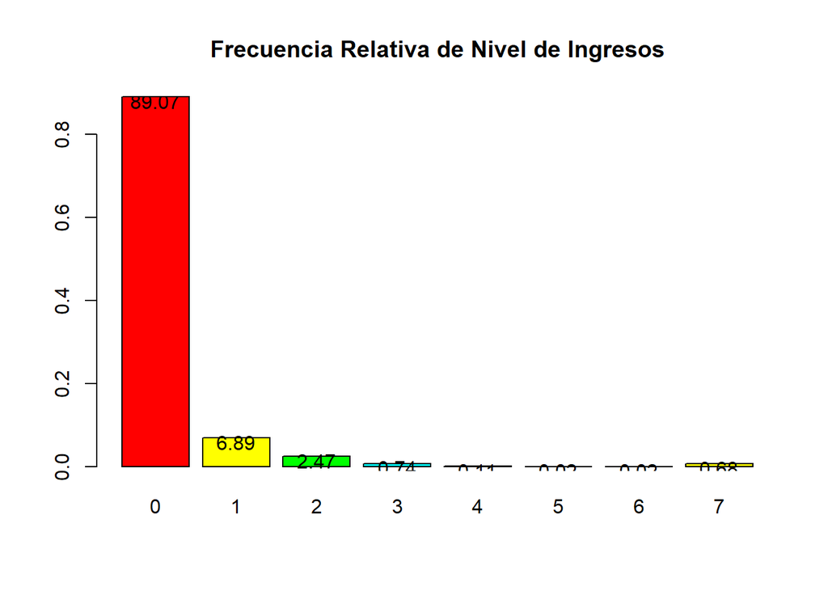

```r
b <- barplot(prop.table(table(DatosSegurosModelo$Puntaje_Morosidad2)), main = 'Frecuencia Relativa de Nivel de Ingresos', col = rainbow(6))
text(b, prop.table(table(DatosSegurosModelo$Puntaje_Morosidad2)) - 0.01, labels = round(prop.table(table(DatosSegurosModelo$Puntaje_Morosidad2)), 4)*100)
```

### **6. Puntaje Morosidad 3:**

#### **Frecuencia Absoluta y Frecuencia Relativa**

```r
# if (require("modeest")) install.packages("modeest")
library('modeest')
paste('Moda = ', mlv(DatosSegurosModelo$Puntaje_Morosidad3, method = "mfv", na.rm = T))
```

```
## [1] "Moda =  0"
```

```r
table(DatosSegurosModelo$Puntaje_Morosidad3)
```

```
##
##    0    1    2    3    4    5    6    7
## 4247  338   84   21    4    2   10   25
```

```r
round(table(DatosSegurosModelo$Puntaje_Morosidad3) / nrow(DatosSegurosModelo) * 100, 2)
```

```
##
##     0     1     2     3     4     5     6     7
## 89.75  7.14  1.78  0.44  0.08  0.04  0.21  0.53
```

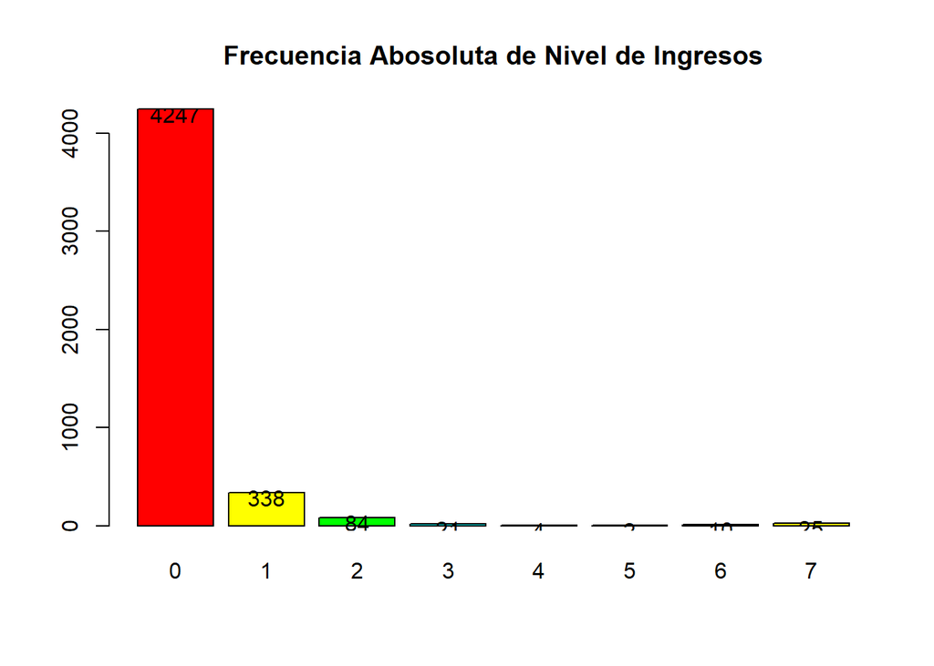

```r
a <- barplot(table(DatosSegurosModelo$Puntaje_Morosidad3), main = 'Frecuencia Abosoluta de Nivel de Ingresos', col = rainbow(6))
text(a, table(DatosSegurosModelo$Puntaje_Morosidad3) - 50, labels = table(DatosSegurosModelo$Puntaje_Morosidad3))
```

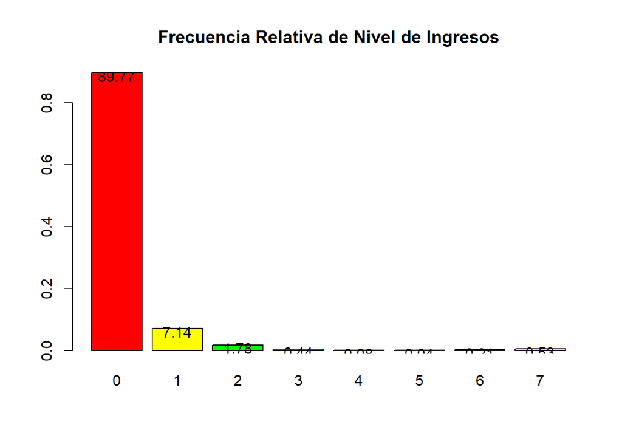

```r
b <- barplot(prop.table(table(DatosSegurosModelo$Puntaje_Morosidad3)), main = 'Frecuencia Relativa de Nivel de Ingresos', col = rainbow(6))
text(b, prop.table(table(DatosSegurosModelo$Puntaje_Morosidad3)) - 0.01, labels = round(prop.table(table(DatosSegurosModelo$Puntaje_Morosidad3)), 4)*100)
```

### **7. Puntaje Morosidad 4:**

#### **Frecuencia Absoluta y Frecuencia Relativa**

```r
# if (require("modeest")) install.packages("modeest")
library('modeest')
paste('Moda = ', mlv(DatosSegurosModelo$Puntaje_Morosidad4, method = "mfv", na.rm = T))
```

```
## [1] "Moda =  0"
```

```r
table(DatosSegurosModelo$Puntaje_Morosidad4)
```

```
##
##    0    1    2    3    4    5    6    7
## 4289  322   64   14    3   10    6   21
```

```r
round(table(DatosSegurosModelo$Puntaje_Morosidad4) / nrow(DatosSegurosModelo) * 100, 2)
```

```
##
##     0     1     2     3     4     5     6     7
## 90.64  6.80  1.35  0.30  0.06  0.21  0.13  0.44
```

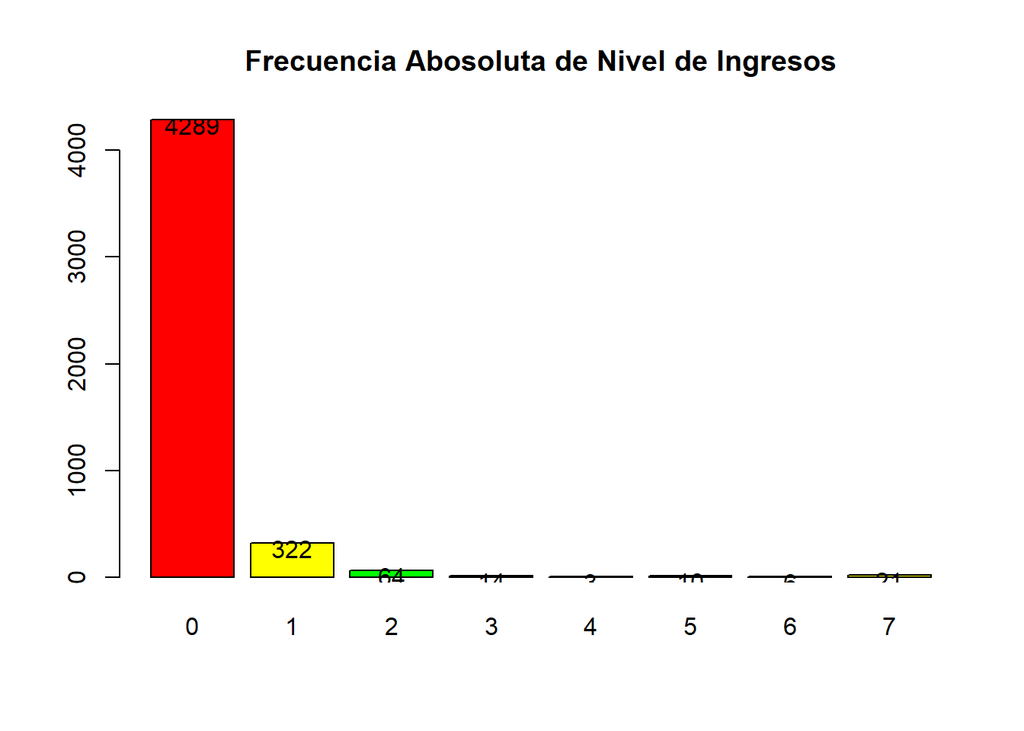

```r
a <- barplot(table(DatosSegurosModelo$Puntaje_Morosidad4), main = 'Frecuencia Abosoluta de Nivel de Ingresos', col = rainbow(6))
text(a, table(DatosSegurosModelo$Puntaje_Morosidad4) - 50, labels = table(DatosSegurosModelo$Puntaje_Morosidad4))
```

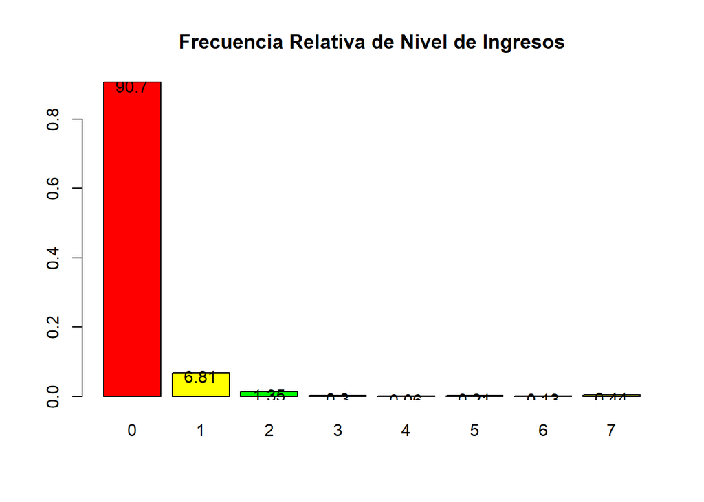

```r
b <- barplot(prop.table(table(DatosSegurosModelo$Puntaje_Morosidad4)), main = 'Frecuencia Relativa de Nivel de Ingresos', col = rainbow(6))
text(b, prop.table(table(DatosSegurosModelo$Puntaje_Morosidad4)) - 0.01, labels = round(prop.table(table(DatosSegurosModelo$Puntaje_Morosidad4)), 4)*100)
```

### **8. Puntaje Morosidad 5:**

#### **Frecuencia Absoluta y Frecuencia Relativa**

```r
# if (require("modeest")) install.packages("modeest")
library('modeest')
paste('Moda = ', mlv(DatosSegurosModelo$Puntaje_Morosidad5, method = "mfv", na.rm = T))
```

```
## [1] "Moda =  0"
```

```r
table(DatosSegurosModelo$Puntaje_Morosidad5)
```

```
##
##    0    1    2    3    4    5    6    7
## 4278  331   68   10   13    7    2   19
```

```r
round(table(DatosSegurosModelo$Puntaje_Morosidad5) / nrow(DatosSegurosModelo) * 100, 2)
```

```
##
##     0     1     2     3     4     5     6     7
## 90.41  6.99  1.44  0.21  0.27  0.15  0.04  0.40
```

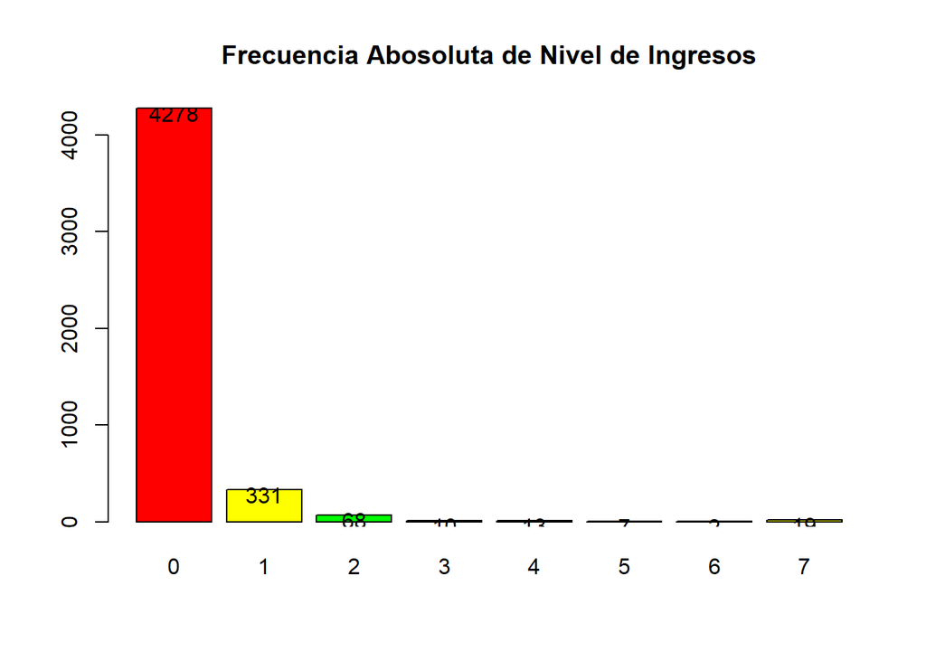

```r
a <- barplot(table(DatosSegurosModelo$Puntaje_Morosidad5), main = 'Frecuencia Abosoluta de Nivel de Ingresos', col = rainbow(6))
text(a, table(DatosSegurosModelo$Puntaje_Morosidad5) - 50, labels = table(DatosSegurosModelo$Puntaje_Morosidad5))
```

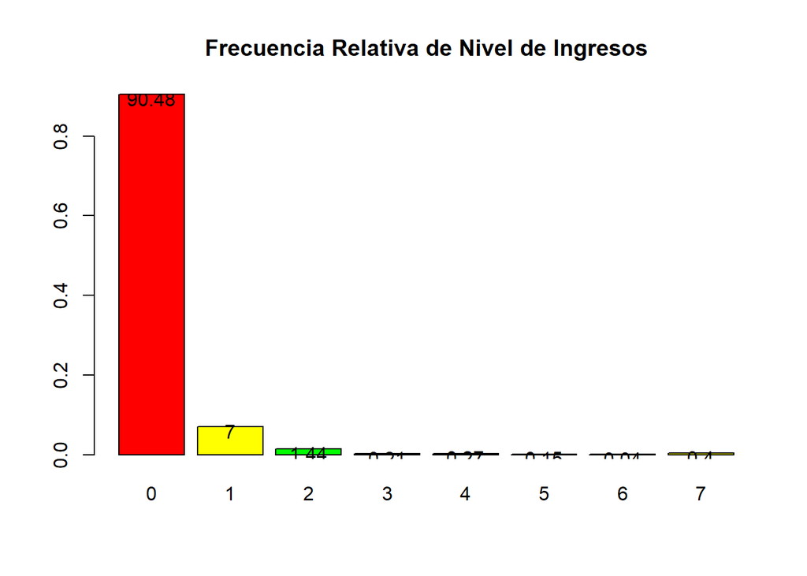

```r
b <- barplot(prop.table(table(DatosSegurosModelo$Puntaje_Morosidad5)), main = 'Frecuencia Relativa de Nivel de Ingresos', col = rainbow(6))
text(b, prop.table(table(DatosSegurosModelo$Puntaje_Morosidad5)) - 0.01, labels = round(prop.table(table(DatosSegurosModelo$Puntaje_Morosidad5)), 4)*100)
```

### **9. Puntaje Morosidad 6:**

#### **Frecuencia Absoluta y Frecuencia Relativa**

```r
# if (require("modeest")) install.packages("modeest")
library('modeest')
paste('Moda = ', mlv(DatosSegurosModelo$Puntaje_Morosidad6, method = "mfv", na.rm = T))
```

```
## [1] "Moda =  0"
```

```r
table(DatosSegurosModelo$Puntaje_Morosidad6)
```

```
##
##    0    1    2    3    4    5    6    7
## 4294  338   46   18    8    3    1   20
```

```r
round(table(DatosSegurosModelo$Puntaje_Morosidad6) / nrow(DatosSegurosModelo) * 100, 2)
```

```
##
##     0     1     2     3     4     5     6     7
## 90.74  7.14  0.97  0.38  0.17  0.06  0.02  0.42
```

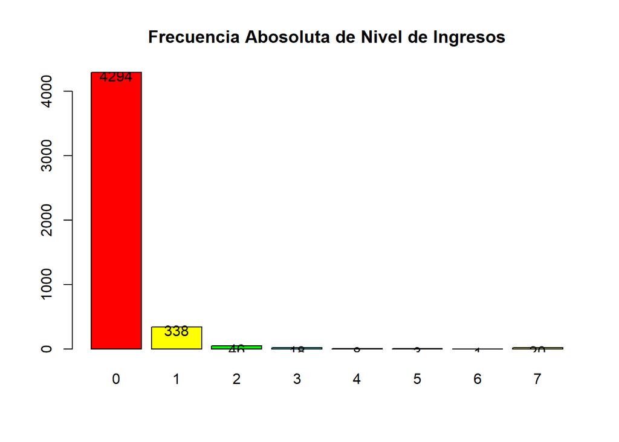

```r
a <- barplot(table(DatosSegurosModelo$Puntaje_Morosidad6), main = 'Frecuencia Abosoluta de Nivel de Ingresos', col = rainbow(6))
text(a, table(DatosSegurosModelo$Puntaje_Morosidad6) - 50, labels = table(DatosSegurosModelo$Puntaje_Morosidad6))
```

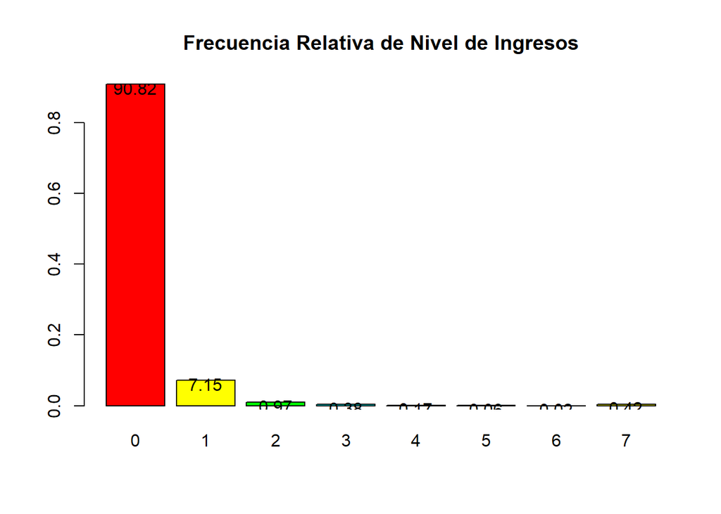

```r
b <- barplot(prop.table(table(DatosSegurosModelo$Puntaje_Morosidad6)), main = 'Frecuencia Relativa de Nivel de Ingresos', col = rainbow(6))
text(b, prop.table(table(DatosSegurosModelo$Puntaje_Morosidad6)) - 0.01, labels = round(prop.table(table(DatosSegurosModelo$Puntaje_Morosidad6)), 4)*100)
```

### **10. Saldo Pendiente Seguro:**

#### **Medidas de Tendencia Central y Medidas de Posición:**

```r
# if (require("modeest")) install.packages("modeest")
library('modeest')
paste('Media = ', mean(DatosSegurosModelo$Saldo_Pendiente_Seg, na.rm = T))
```

```
## [1] "Media =  5548.86254015216"
```

```r
paste('Mediana = ', median(DatosSegurosModelo$Saldo_Pendiente_Seg, na.rm = T))
```

```
## [1] "Mediana =  0"
```

```r
paste('Moda = ', mlv(DatosSegurosModelo$Saldo_Pendiente_Seg, method = "mfv", na.rm = T))
```

```
## [1] "Moda =  0"
```

```r
paste('Percentiles:')
```

```
## [1] "Percentiles:"
```

```r
quantile(DatosSegurosModelo$Saldo_Pendiente_Seg, c(0.01, 0.05, 0.10, 0.20, 0.25, 0.30, 0.40, 0.50, 0.60, 0.70, 0.75, 0.80, 0.90, 0.95, 0.99), na.rm = T)
```

```
##        1%        5%       10%       20%       25%       30%       40%       50%
##      0.00      0.00      0.00      0.00      0.00      0.00      0.00      0.00
##       60%       70%       75%       80%       90%       95%       99%
##      0.00      0.00      0.00      0.00      0.00  46082.44 117955.22
```

```r
paste('Histograma:')
```

```
## [1] "Histograma:"
```

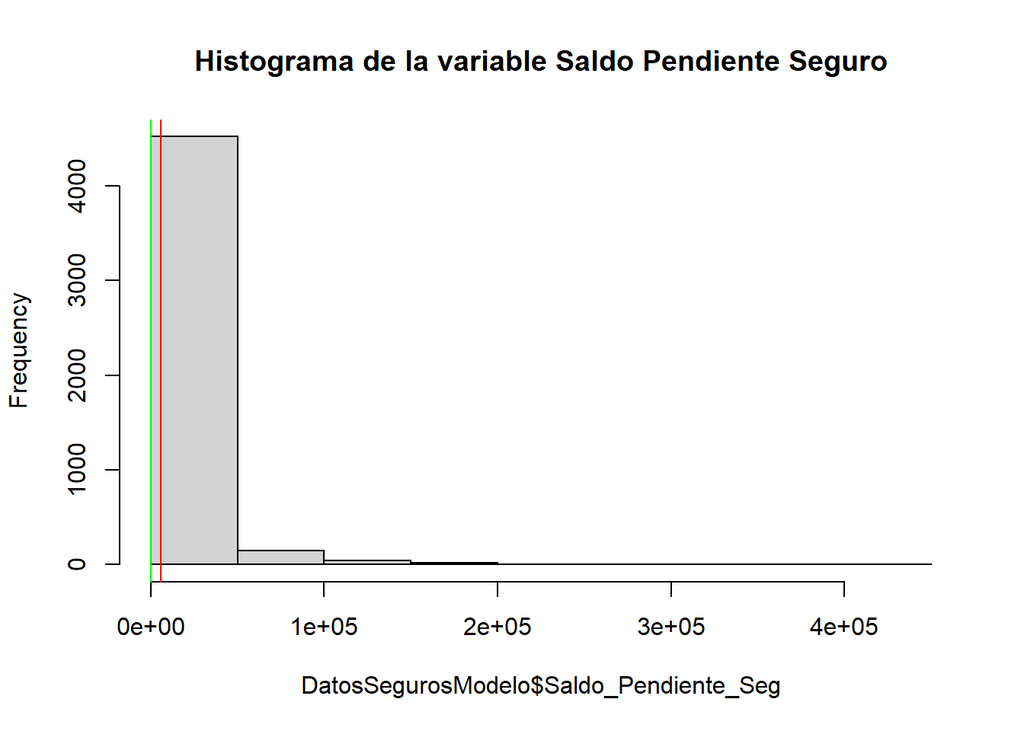

```r
hist(DatosSegurosModelo$Saldo_Pendiente_Seg, main= "Histograma de la variable Saldo Pendiente Seguro")
abline(v=mean(DatosSegurosModelo$Saldo_Pendiente_Seg, na.rm = T), col="red")
abline(v=median(DatosSegurosModelo$Saldo_Pendiente_Seg, na.rm = T), col="blue")
abline(v=mlv(DatosSegurosModelo$Saldo_Pendiente_Seg, method = "mfv", na.rm = T), col="green")
```

```r
paste('Boxplot:')
```

```
## [1] "Boxplot:"
```

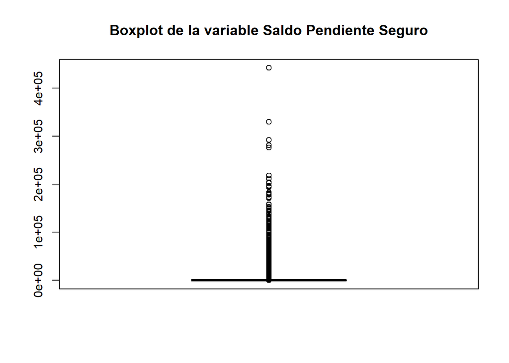

```r
boxplot(DatosSegurosModelo$Saldo_Pendiente_Seg, main= "Boxplot de la variable Saldo Pendiente Seguro")
```

#### **Medidas de Dispersión:**

```r
paste('Desviación Estándar: ', sd(DatosSegurosModelo$Saldo_Pendiente_Seg, na.rm = TRUE))
```

```
## [1] "Desviación Estándar:  23290.8457653944"
```

```r
paste('Varianza: ', sd(DatosSegurosModelo$Saldo_Pendiente_Seg, na.rm = TRUE)^2)
```

```
## [1] "Varianza:  542463496.467391"
```

```r
paste('Coeficiente de Variación: ', sd(DatosSegurosModelo$Saldo_Pendiente_Seg, na.rm = TRUE) / mean(DatosSegurosModelo$Saldo_Pendiente_Seg, na.rm = T) * 100)
```

```
## [1] "Coeficiente de Variación:  419.740903597078"
```

#### **Asimetría y Curtosis:**

```r
library(e1071)
skewness(DatosSegurosModelo$Saldo_Pendiente_Seg, na.rm = TRUE)
```

```
## [1] 6.719532
```

```r
kurtosis(DatosSegurosModelo$Saldo_Pendiente_Seg, na.rm = TRUE)
```

```
## [1] 66.17883
```

### **11. Siniestros1:**

#### **Medidas de Tendencia Central y Medidas de Posición:**

```r
# if (require("modeest")) install.packages("modeest")
library('modeest')
paste('Media = ', mean(DatosSegurosModelo$Siniestros1, na.rm = T))
```

```
## [1] "Media =  0.633770076077768"
```

```r
paste('Mediana = ', median(DatosSegurosModelo$Siniestros1, na.rm = T))
```

```
## [1] "Mediana =  0"
```

```r
paste('Moda = ', mlv(DatosSegurosModelo$Siniestros1, method = "mfv", na.rm = T))
```

```
## [1] "Moda =  0"
```

```r
paste('Percentiles:')
```

```
## [1] "Percentiles:"
```

```r
quantile(DatosSegurosModelo$Siniestros1, c(0.01, 0.05, 0.10, 0.20, 0.25, 0.30, 0.40, 0.50, 0.60, 0.70, 0.75, 0.80, 0.90, 0.95, 0.99), na.rm = T)
```

```
##  1%  5% 10% 20% 25% 30% 40% 50% 60% 70% 75% 80% 90% 95% 99%
##   0   0   0   0   0   0   0   0   0   0   0   0   1   3  13
```

```r
paste('Histograma:')
```

```
## [1] "Histograma:"
```

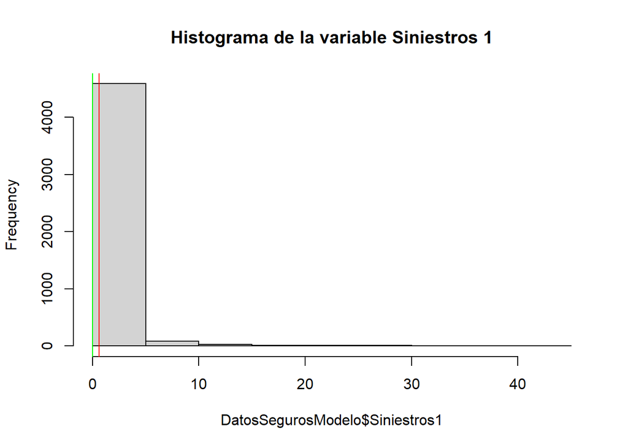

```r
hist(DatosSegurosModelo$Siniestros1, main= "Histograma de la variable Siniestros 1")
abline(v=mean(DatosSegurosModelo$Siniestros1, na.rm = T), col="red")
abline(v=median(DatosSegurosModelo$Siniestros1, na.rm = T), col="blue")
abline(v=mlv(DatosSegurosModelo$Siniestros1, method = "mfv", na.rm = T), col="green")
```

```r
paste('Boxplot:')
```

```
## [1] "Boxplot:"
```

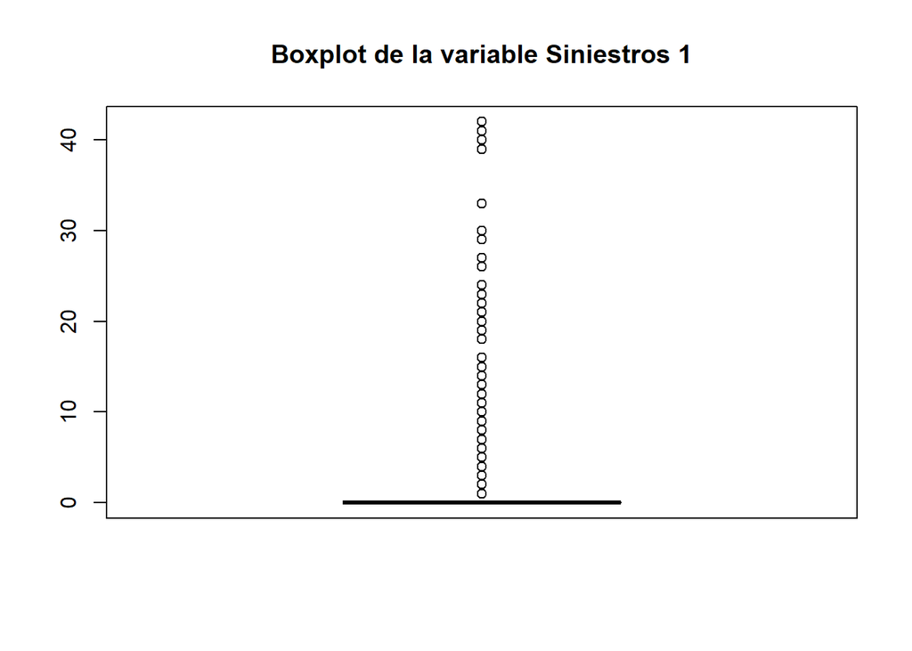

```r
boxplot(DatosSegurosModelo$Siniestros1, main= "Boxplot de la variable Siniestros 1")
```

#### **Medidas de Dispersión:**

```r
paste('Desviación Estándar: ', sd(DatosSegurosModelo$Siniestros1, na.rm = TRUE))
```

```
## [1] "Desviación Estándar:  2.66649453346269"
```

```r
paste('Varianza: ', sd(DatosSegurosModelo$Siniestros1, na.rm = TRUE)^2)
```

```
## [1] "Varianza:  7.11019309698642"
```

```r
paste('Coeficiente de Variación: ', sd(DatosSegurosModelo$Siniestros1, na.rm = TRUE) / mean(DatosSegurosModelo$Siniestros1, na.rm = T) * 100)
```

```
## [1] "Coeficiente de Variación:  420.735316183577"
```

#### **Asimetría y Curtosis:**

```r
library(e1071)
skewness(DatosSegurosModelo$Siniestros1, na.rm = TRUE)
```

```
## [1] 8.21094
```

```r
kurtosis(DatosSegurosModelo$Siniestros1, na.rm = TRUE)
```

```
## [1] 87.64679
```

### **12. Siniestros2:**

#### **Medidas de Tendencia Central y Medidas de Posición:**

```r
# if (require("modeest")) install.packages("modeest")
library('modeest')
paste('Media = ', mean(DatosSegurosModelo$Siniestros2, na.rm = T))
```

```
## [1] "Media =  0.550718512256974"
```

```r
paste('Mediana = ', median(DatosSegurosModelo$Siniestros2, na.rm = T))
```

```
## [1] "Mediana =  0"
```

```r
paste('Moda = ', mlv(DatosSegurosModelo$Siniestros2, method = "mfv", na.rm = T))
```

```
## [1] "Moda =  0"
```

```r
paste('Percentiles:')
```

```
## [1] "Percentiles:"
```

```r
quantile(DatosSegurosModelo$Siniestros2, c(0.01, 0.05, 0.10, 0.20, 0.25, 0.30, 0.40, 0.50, 0.60, 0.70, 0.75, 0.80, 0.90, 0.95, 0.99), na.rm = T)
```

```
##  1%  5% 10% 20% 25% 30% 40% 50% 60% 70% 75% 80% 90% 95% 99%
##   0   0   0   0   0   0   0   0   0   0   0   0   1   3  11
```

```r
paste('Histograma:')
```

```
## [1] "Histograma:"
```

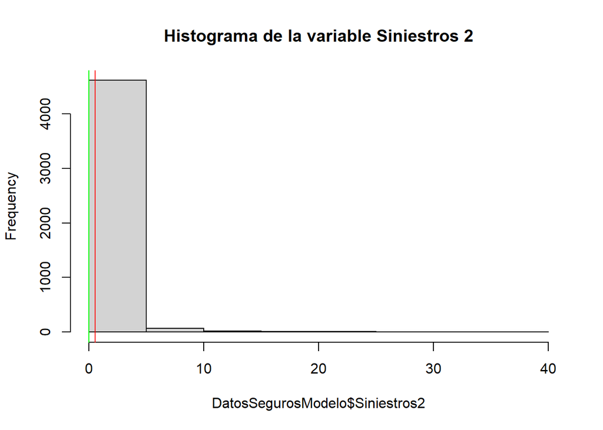

```r
hist(DatosSegurosModelo$Siniestros2, main= "Histograma de la variable Siniestros 2")
abline(v=mean(DatosSegurosModelo$Siniestros2, na.rm = T), col="red")
abline(v=median(DatosSegurosModelo$Siniestros2, na.rm = T), col="blue")
abline(v=mlv(DatosSegurosModelo$Siniestros2, method = "mfv", na.rm = T), col="green")
```

```r
paste('Boxplot:')
```

```
## [1] "Boxplot:"
```

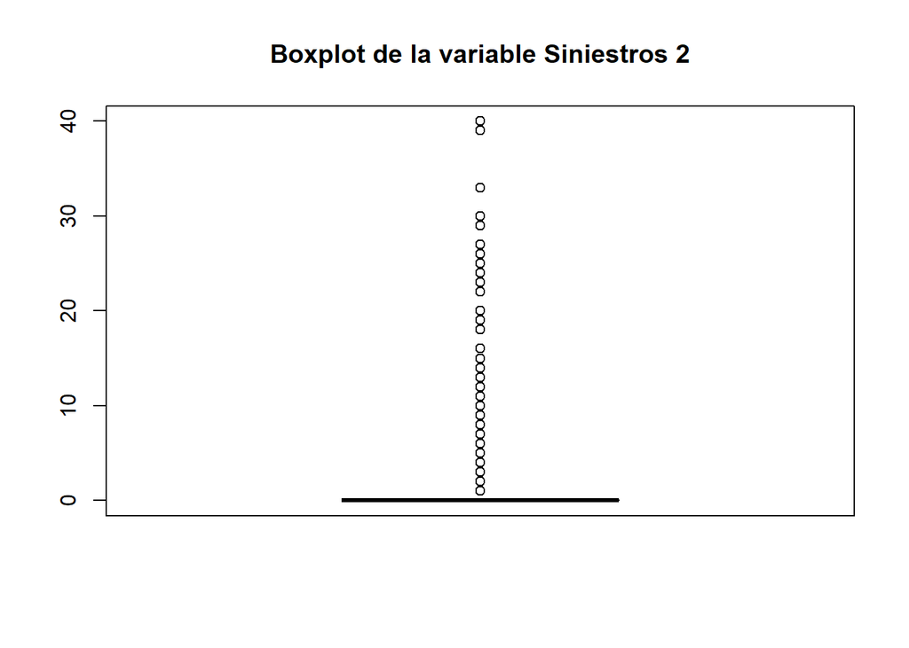

```r
boxplot(DatosSegurosModelo$Siniestros2, main= "Boxplot de la variable Siniestros 2")
```

#### **Medidas de Dispersión:**

```r
paste('Desviación Estándar: ', sd(DatosSegurosModelo$Siniestros2, na.rm = TRUE))
```

```
## [1] "Desviación Estándar:  2.42759568089679"
```

```r
paste('Varianza: ', sd(DatosSegurosModelo$Siniestros2, na.rm = TRUE)^2)
```

```
## [1] "Varianza:  5.89322078990876"
```

```r
paste('Coeficiente de Variación: ', sd(DatosSegurosModelo$Siniestros2, na.rm = TRUE) / mean(DatosSegurosModelo$Siniestros2, na.rm = T) * 100)
```

```
## [1] "Coeficiente de Variación:  440.8051712204"
```

#### **Asimetría y Curtosis:**

```r
library(e1071)
skewness(DatosSegurosModelo$Siniestros2, na.rm = TRUE)
```

```
## [1] 8.610725
```

```r
kurtosis(DatosSegurosModelo$Siniestros2, na.rm = TRUE)
```

```
## [1] 95.73858
```

### **13. Siniestros3:**

#### **Medidas de Tendencia Central y Medidas de Posición:**

```r
# if (require("modeest")) install.packages("modeest")
library('modeest')
paste('Media = ', mean(DatosSegurosModelo$Siniestros3, na.rm = T))
```

```
## [1] "Media =  0.493026204564666"
```

```r
paste('Mediana = ', median(DatosSegurosModelo$Siniestros3, na.rm = T))
```

```
## [1] "Mediana =  0"
```

```r
paste('Moda = ', mlv(DatosSegurosModelo$Siniestros3, method = "mfv", na.rm = T))
```

```
## [1] "Moda =  0"
```

```r
paste('Percentiles:')
```

```
## [1] "Percentiles:"
```

```r
quantile(DatosSegurosModelo$Siniestros3, c(0.01, 0.05, 0.10, 0.20, 0.25, 0.30, 0.40, 0.50, 0.60, 0.70, 0.75, 0.80, 0.90, 0.95, 0.99), na.rm = T)
```

```
##  1%  5% 10% 20% 25% 30% 40% 50% 60% 70% 75% 80% 90% 95% 99%
##   0   0   0   0   0   0   0   0   0   0   0   0   1   2  10
```

```r
paste('Histograma:')
```

```
## [1] "Histograma:"
```

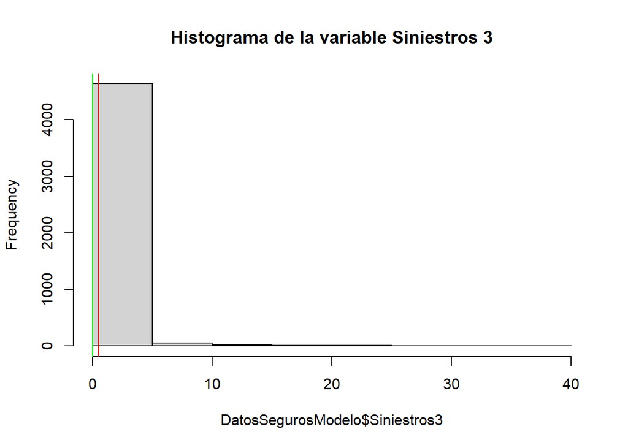

```r
hist(DatosSegurosModelo$Siniestros3, main= "Histograma de la variable Siniestros 3")
abline(v=mean(DatosSegurosModelo$Siniestros3, na.rm = T), col="red")
abline(v=median(DatosSegurosModelo$Siniestros3, na.rm = T), col="blue")
abline(v=mlv(DatosSegurosModelo$Siniestros3, method = "mfv", na.rm = T), col="green")
```

```r
paste('Boxplot:')
```

```
## [1] "Boxplot:"
```

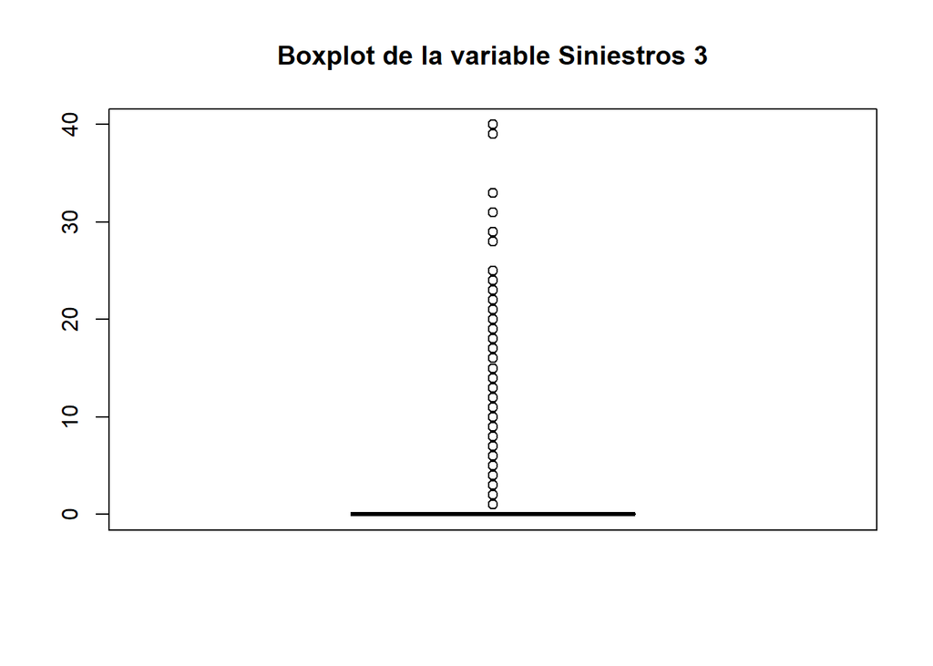

```r
boxplot(DatosSegurosModelo$Siniestros3, main= "Boxplot de la variable Siniestros 3")
```

#### **Medidas de Dispersión:**

```r
paste('Desviación Estándar: ', sd(DatosSegurosModelo$Siniestros3, na.rm = TRUE))
```

```
## [1] "Desviación Estándar:  2.27355422154357"
```

```r
paste('Varianza: ', sd(DatosSegurosModelo$Siniestros3, na.rm = TRUE)^2)
```

```
## [1] "Varianza:  5.16904879829859"
```

```r
paste('Coeficiente de Variación: ', sd(DatosSegurosModelo$Siniestros3, na.rm = TRUE) / mean(DatosSegurosModelo$Siniestros3, na.rm = T) * 100)
```

```
## [1] "Coeficiente de Variación:  461.142673653844"
```

#### **Asimetría y Curtosis:**

```r
library(e1071)
skewness(DatosSegurosModelo$Siniestros3, na.rm = TRUE)
```

```
## [1] 9.285958
```

```r
kurtosis(DatosSegurosModelo$Siniestros3, na.rm = TRUE)
```

```
## [1] 111.428
```

### **14. Siniestros4:**

#### **Medidas de Tendencia Central y Medidas de Posición:**

```r
# if (require("modeest")) install.packages("modeest")
library('modeest')
paste('Media = ', mean(DatosSegurosModelo$Siniestros4, na.rm = T))
```

```
## [1] "Media =  0.460693153000845"
```

```r
paste('Mediana = ', median(DatosSegurosModelo$Siniestros4, na.rm = T))
```

```
## [1] "Mediana =  0"
```

```r
paste('Moda = ', mlv(DatosSegurosModelo$Siniestros4, method = "mfv", na.rm = T))
```

```
## [1] "Moda =  0"
```

```r
paste('Percentiles:')
```

```
## [1] "Percentiles:"
```

```r
quantile(DatosSegurosModelo$Siniestros4, c(0.01, 0.05, 0.10, 0.20, 0.25, 0.30, 0.40, 0.50, 0.60, 0.70, 0.75, 0.80, 0.90, 0.95, 0.99), na.rm = T)
```

```
##   1%   5%  10%  20%  25%  30%  40%  50%  60%  70%  75%  80%  90%  95%  99%
## 0.00 0.00 0.00 0.00 0.00 0.00 0.00 0.00 0.00 0.00 0.00 0.00 1.00 2.00 9.69
```

```r
paste('Histograma:')
```

```
## [1] "Histograma:"
```

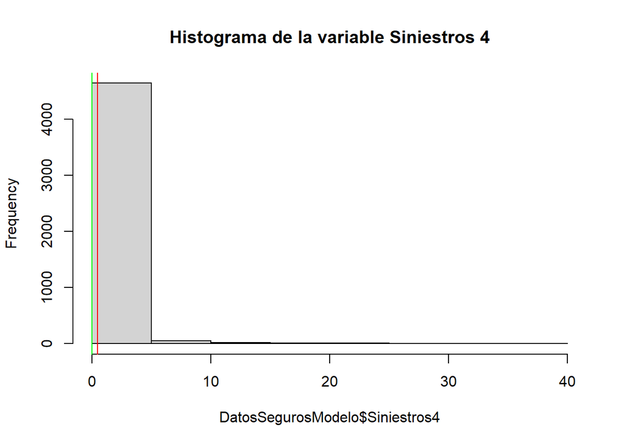

```r
hist(DatosSegurosModelo$Siniestros4, main= "Histograma de la variable Siniestros 4")
abline(v=mean(DatosSegurosModelo$Siniestros4, na.rm = T), col="red")
abline(v=median(DatosSegurosModelo$Siniestros4, na.rm = T), col="blue")
abline(v=mlv(DatosSegurosModelo$Siniestros4, method = "mfv", na.rm = T), col="green")
```

```r
paste('Boxplot:')
```

```
## [1] "Boxplot:"
```

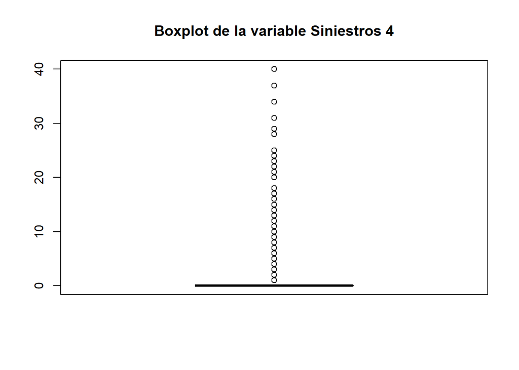

```r
boxplot(DatosSegurosModelo$Siniestros4, main= "Boxplot de la variable Siniestros 4")
```

#### **Medidas de Dispersión:**

```r
paste('Desviación Estándar: ', sd(DatosSegurosModelo$Siniestros4, na.rm = TRUE))
```

```
## [1] "Desviación Estándar:  2.24703891330879"
```

```r
paste('Varianza: ', sd(DatosSegurosModelo$Siniestros4, na.rm = TRUE)^2)
```

```
## [1] "Varianza:  5.04918387792394"
```

```r
paste('Coeficiente de Variación: ', sd(DatosSegurosModelo$Siniestros4, na.rm = TRUE) / mean(DatosSegurosModelo$Siniestros4, na.rm = T) * 100)
```

```
## [1] "Coeficiente de Variación:  487.75174943932"
```

#### **Asimetría y Curtosis:**

```r
library(e1071)
skewness(DatosSegurosModelo$Siniestros4, na.rm = TRUE)
```

```
## [1] 9.909356
```

```r
kurtosis(DatosSegurosModelo$Siniestros4, na.rm = TRUE)
```

```
## [1] 125.315
```

### **15. Siniestros5:**

#### **Medidas de Tendencia Central y Medidas de Posición:**

```r
# if (require("modeest")) install.packages("modeest")
library('modeest')
paste('Media = ', mean(DatosSegurosModelo$Siniestros5, na.rm = T))
```

```
## [1] "Media =  0.418005071851226"
```

```r
paste('Mediana = ', median(DatosSegurosModelo$Siniestros5, na.rm = T))
```

```
## [1] "Mediana =  0"
```

```r
paste('Moda = ', mlv(DatosSegurosModelo$Siniestros5, method = "mfv", na.rm = T))
```

```
## [1] "Moda =  0"
```

```r
paste('Percentiles:')
```

```
## [1] "Percentiles:"
```

```r
quantile(DatosSegurosModelo$Siniestros5, c(0.01, 0.05, 0.10, 0.20, 0.25, 0.30, 0.40, 0.50, 0.60, 0.70, 0.75, 0.80, 0.90, 0.95, 0.99), na.rm = T)
```

```
##  1%  5% 10% 20% 25% 30% 40% 50% 60% 70% 75% 80% 90% 95% 99%
##   0   0   0   0   0   0   0   0   0   0   0   0   1   2   8
```

```r
paste('Histograma:')
```

```
## [1] "Histograma:"
```

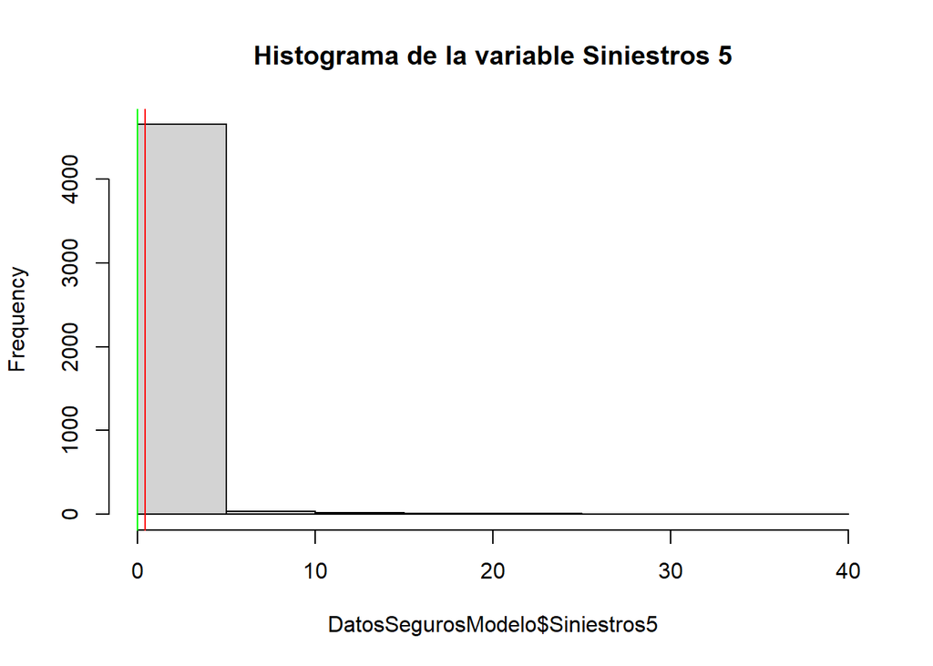

```r
hist(DatosSegurosModelo$Siniestros5, main= "Histograma de la variable Siniestros 5")
abline(v=mean(DatosSegurosModelo$Siniestros5, na.rm = T), col="red")
abline(v=median(DatosSegurosModelo$Siniestros5, na.rm = T), col="blue")
abline(v=mlv(DatosSegurosModelo$Siniestros5, method = "mfv", na.rm = T), col="green")
```

```r
paste('Boxplot:')
```

```
## [1] "Boxplot:"
```

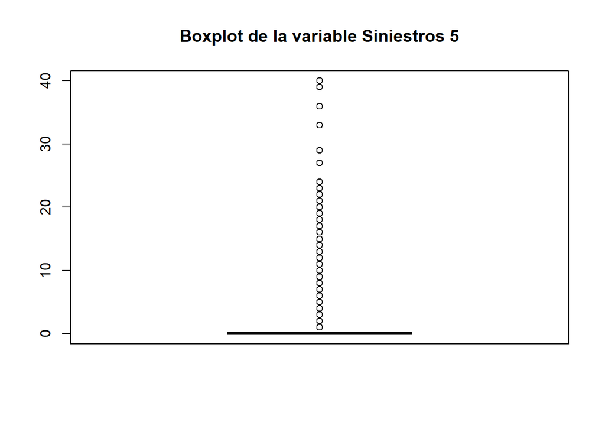

```r
boxplot(DatosSegurosModelo$Siniestros5, main= "Boxplot de la variable Siniestros 5")
```

#### **Medidas de Dispersión:**

```r
paste('Desviación Estándar: ', sd(DatosSegurosModelo$Siniestros5, na.rm = TRUE))
```

```
## [1] "Desviación Estándar:  2.12737419896698"
```

```r
paste('Varianza: ', sd(DatosSegurosModelo$Siniestros5, na.rm = TRUE)^2)
```

```
## [1] "Varianza:  4.52572098243041"
```

```r
paste('Coeficiente de Variación: ', sd(DatosSegurosModelo$Siniestros5, na.rm = TRUE) / mean(DatosSegurosModelo$Siniestros5, na.rm = T) * 100)
```

```
## [1] "Coeficiente de Variación:  508.935020703325"
```

#### **Asimetría y Curtosis:**

```r
library(e1071)
skewness(DatosSegurosModelo$Siniestros5, na.rm = TRUE)
```

```
## [1] 10.41287
```

```r
kurtosis(DatosSegurosModelo$Siniestros5, na.rm = TRUE)
```

```
## [1] 137.8821
```

### **16. Siniestros6:**

#### **Medidas de Tendencia Central y Medidas de Posición:**

```r
# if (require("modeest")) install.packages("modeest")
library('modeest')
paste('Media = ', mean(DatosSegurosModelo$Siniestros6, na.rm = T))
```

```
## [1] "Media =  0.384826711749789"
```

```r
paste('Mediana = ', median(DatosSegurosModelo$Siniestros6, na.rm = T))
```

```
## [1] "Mediana =  0"
```

```r
paste('Moda = ', mlv(DatosSegurosModelo$Siniestros6, method = "mfv", na.rm = T))
```

```
## [1] "Moda =  0"
```

```r
paste('Percentiles:')
```

```
## [1] "Percentiles:"
```

```r
quantile(DatosSegurosModelo$Siniestros6, c(0.01, 0.05, 0.10, 0.20, 0.25, 0.30, 0.40, 0.50, 0.60, 0.70, 0.75, 0.80, 0.90, 0.95, 0.99), na.rm = T)
```

```
##  1%  5% 10% 20% 25% 30% 40% 50% 60% 70% 75% 80% 90% 95% 99%
##   0   0   0   0   0   0   0   0   0   0   0   0   1   2   8
```

```r
paste('Histograma:')
```

```
## [1] "Histograma:"
```

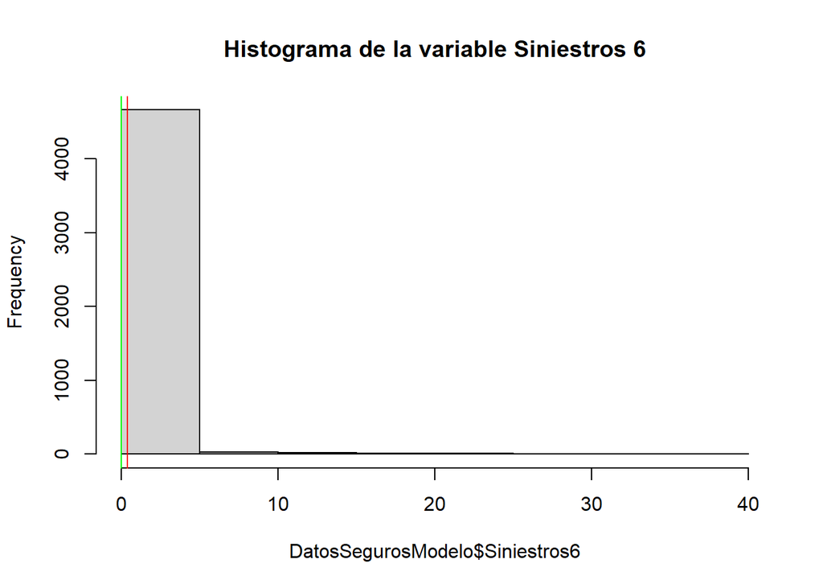

```r
hist(DatosSegurosModelo$Siniestros6, main= "Histograma de la variable Siniestros 6")
abline(v=mean(DatosSegurosModelo$Siniestros6, na.rm = T), col="red")
abline(v=median(DatosSegurosModelo$Siniestros6, na.rm = T), col="blue")
abline(v=mlv(DatosSegurosModelo$Siniestros6, method = "mfv", na.rm = T), col="green")
```

```r
paste('Boxplot:')
```

```
## [1] "Boxplot:"
```

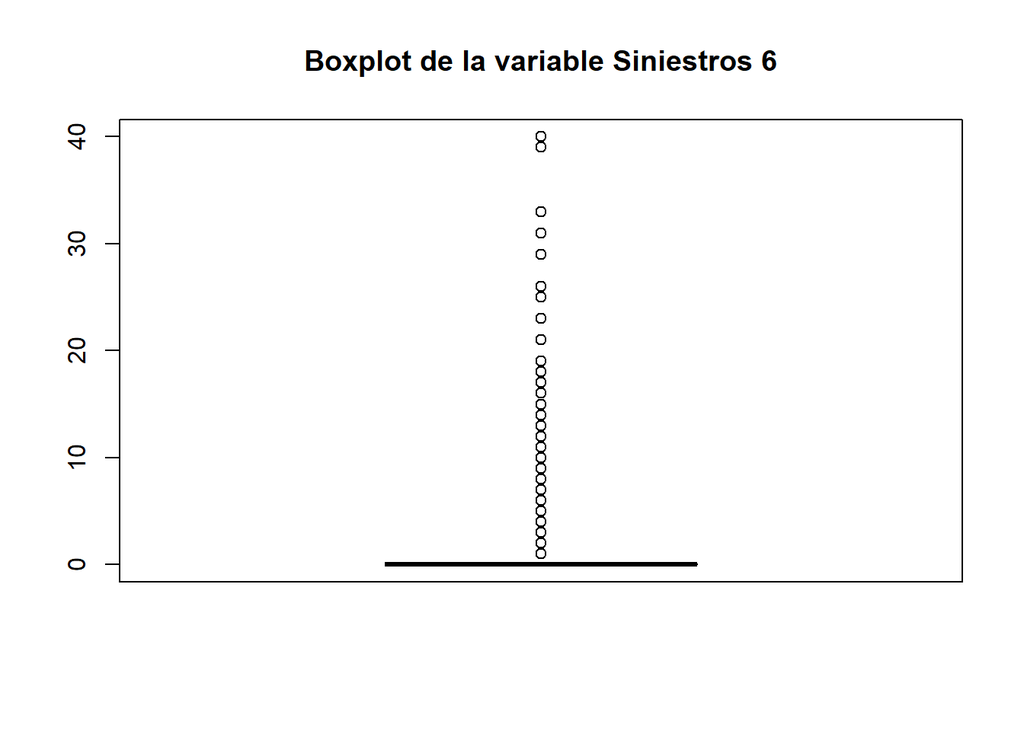

```r
boxplot(DatosSegurosModelo$Siniestros6, main= "Boxplot de la variable Siniestros 6")
```

#### **Medidas de Dispersión:**

```r
paste('Desviación Estándar: ', sd(DatosSegurosModelo$Siniestros6, na.rm = TRUE))
```

```
## [1] "Desviación Estándar:  2.07583099250106"
```

```r
paste('Varianza: ', sd(DatosSegurosModelo$Siniestros6, na.rm = TRUE)^2)
```

```
## [1] "Varianza:  4.30907430942795"
```

```r
paste('Coeficiente de Variación: ', sd(DatosSegurosModelo$Siniestros6, na.rm = TRUE) / mean(DatosSegurosModelo$Siniestros6, na.rm = T) * 100)
```

```
## [1] "Coeficiente de Variación:  539.419673614225"
```

#### **Asimetría y Curtosis:**

```r
library(e1071)
skewness(DatosSegurosModelo$Siniestros6, na.rm = TRUE)
```

```
## [1] 10.97943
```

```r
kurtosis(DatosSegurosModelo$Siniestros6, na.rm = TRUE)
```

```
## [1] 153.2467
```